# 1. Mise en place de l'environnement de développement

## 1.1 Importations

```python
# Utilitaires
import sys
import pandas as pd
import numpy as np
import pickle
import os
import json

# Visualisations
import matplotlib
import matplotlib.pyplot as plt
from matplotlib import rcParams
rcParams['font.family'] = 'DejaVu Sans'
import seaborn as sns

# Sklearn
import sklearn
from sklearn.decomposition import PCA
from sklearn.manifold import TSNE
from sklearn.cluster import KMeans
from sklearn.metrics import silhouette_score
from sklearn.preprocessing import normalize

# Surprise
import surprise
from surprise import Dataset, Reader, SVD
from surprise.model_selection import train_test_split
from surprise.model_selection import GridSearchCV
from surprise import accuracy
```

## 1.2 Vérification des versions

```python
librairies = {
    'Python': sys.version[0:6],
    'numpy' : np.__version__,
    'matplotlib' : matplotlib.__version__,
    'sklearn' : sklearn.__version__,
    'surprise' : surprise.__version__
}
print('La version importée de :')
for nom in librairies:
    print(f'- {nom} est {librairies[nom]}')
```

```
La version importée de :
- Python est 3.11.7
- numpy est 1.26.4
- matplotlib est 3.8.4
- sklearn est 1.5.0
- surprise est 1.1.4
```

# 2. Le dataset

## 2.1 Présentation

Source : [https://www.kaggle.com/datasets/gspmoreira/news-portal-user-interactions-by-globocom#clicks_sample.csv]

Le but de ce projet est de créer un modèle permettant de recommander des articles et livres à des particuliers. Pour cela le dosssier News Portal User Interactions by Globo.com a été téléchargé. Il comprend les éléments suivants:

- articles_metadata.csv qui contient les métadonnées des articles.
- clicks_sample.csv qui contient des exemples d'interactions utilisateurs-articles.
- articles_embeddings.pickle qui contient des embeddings des articles.
- fichier clicks qui contient toutes les interactions utilisateurs-articles .

## 2.2 Exploration

### articles_metadata.csv

Ce fichier contient des métadonnées sur les articles disponibles (364047 articles totaux). Chaque ligne représente un article avec les informations suivantes :

- article_id: Identifiant unique de l'article.
- category_id: Catégorie à laquelle appartient l'article.
- created_at_ts: Timestamp indiquant quand l'article a été créé.
- publisher_id: Identifiant de l'éditeur de l'article.
- words_count: Nombre de mots dans l'article.

Ces métadonnées vont pouvoir être utilisées pour le filtrage basé sur le contenu. Les informations telles que la catégorie et le nombre de mots peuvent aider à trouver des articles similaires à recommander aux utilisateurs.

```python
articles_metadata = pd.read_csv('data/articles_metadata.csv')
articles_metadata.head()
```

|  | article_id | category_id | created_at_ts | publisher_id | words_count |
| --- | --- | --- | --- | --- | --- |
| 0 | 0 | 0 | 1513144419000 | 0 | 168 |
| 1 | 1 | 1 | 1405341936000 | 0 | 189 |
| 2 | 2 | 1 | 1408667706000 | 0 | 250 |
| 3 | 3 | 1 | 1408468313000 | 0 | 230 |
| 4 | 4 | 1 | 1407071171000 | 0 | 162 |

```python
articles_metadata = articles_metadata[['article_id', 'category_id','words_count']].copy()
```

```python
articles_metadata.info()
```

```
<class 'pandas.core.frame.DataFrame'>
RangeIndex: 364047 entries, 0 to 364046
Data columns (total 3 columns):
 #   Column       Non-Null Count   Dtype
---  ------       --------------   -----
 0   article_id   364047 non-null  int64
 1   category_id  364047 non-null  int64
 2   words_count  364047 non-null  int64
dtypes: int64(3)
memory usage: 8.3 MB
```

```python
print("Nombre d'articles:", articles_metadata['article_id'].nunique())
```

```
Nombre d'articles: 364047
```

### clicks_sample.csv

Ces interactions vont être essentielles pour entraîner des modèles de recommandation collaborative. En analysant quels articles ont été cliqués par quels utilisateurs, nous pouvons déterminer des similarités entre les utilisateurs et recommander des articles que des utilisateurs similaires ont cliqué.

```python
clicks_sample = pd.read_csv('data/clicks_sample.csv', delimiter=',')
clicks_sample.head()
```

|  | user_id | session_id | session_start | session_size | click_article_id | click_timestamp | click_environment | click_deviceGroup | click_os | click_country | click_region | click_referrer_type |
| --- | --- | --- | --- | --- | --- | --- | --- | --- | --- | --- | --- | --- |
| 0 | 0 | 1506825423271737 | 1506825423000 | 2 | 157541 | 1506826828020 | 4 | 3 | 20 | 1 | 20 | 2 |
| 1 | 0 | 1506825423271737 | 1506825423000 | 2 | 68866 | 1506826858020 | 4 | 3 | 20 | 1 | 20 | 2 |
| 2 | 1 | 1506825426267738 | 1506825426000 | 2 | 235840 | 1506827017951 | 4 | 1 | 17 | 1 | 16 | 2 |
| 3 | 1 | 1506825426267738 | 1506825426000 | 2 | 96663 | 1506827047951 | 4 | 1 | 17 | 1 | 16 | 2 |
| 4 | 2 | 1506825435299739 | 1506825435000 | 2 | 119592 | 1506827090575 | 4 | 1 | 17 | 1 | 24 | 2 |

```python
clicks_sample = clicks_sample[['user_id','session_id','click_article_id']].copy()
```

```python
clicks_sample.info()
```

```
<class 'pandas.core.frame.DataFrame'>
RangeIndex: 1883 entries, 0 to 1882
Data columns (total 3 columns):
 #   Column            Non-Null Count  Dtype
---  ------            --------------  -----
 0   user_id           1883 non-null   int64
 1   session_id        1883 non-null   int64
 2   click_article_id  1883 non-null   int64
dtypes: int64(3)
memory usage: 44.3 KB
```

Fichier clicks

Ce fichier contient un grand nombre de fichiers CSV (385) qui enregistrent les interactions utilisateur-article de manière détaillée.

- Chaque fichier clicks_hour_000.csv, clicks_hour_001.csv, etc., contient des interactions utilisateur-article pour une tranche horaire spécifique. Par exemple, clicks_hour_000.csv pourrait contenir les clics enregistrés de 00:00 à 01:00, clicks_hour_001.csv de 01:00 à 02:00, etc.
- Chaque fichier suit le même format que clicks_sample.csv.

Ces données permettent de suivre les comportements des utilisateurs heure par heure, ce qui peut être utile pour des analyses temporelles et pour ajuster les recommandations en fonction des moments de la journée.

```python
clicks_dir = 'data/clicks'
clicks_files = os.listdir(clicks_dir)
len(clicks_files)
```

```
385
```

```python
clicks_hour_000 = pd.read_csv(f'{clicks_dir}/clicks_hour_000.csv')
print(clicks_hour_000.head())
print(clicks_hour_000.shape)
```

```
   user_id        session_id  session_start  session_size  click_article_id  \
0        0  1506825423271737  1506825423000             2            157541
1        0  1506825423271737  1506825423000             2             68866
2        1  1506825426267738  1506825426000             2            235840
3        1  1506825426267738  1506825426000             2             96663
4        2  1506825435299739  1506825435000             2            119592

   click_timestamp  click_environment  click_deviceGroup  click_os  \
0    1506826828020                  4                  3        20
1    1506826858020                  4                  3        20
2    1506827017951                  4                  1        17
3    1506827047951                  4                  1        17
4    1506827090575                  4                  1        17

   click_country  click_region  click_referrer_type
0              1            20                    2
1              1            20                    2
2              1            16                    2
3              1            16                    2
4              1            24                    2
(1883, 12)
```

```python
clicks_hour_001 = pd.read_csv(f'{clicks_dir}/clicks_hour_001.csv')
print(clicks_hour_001.head())
print(clicks_hour_001.shape)
```

```
   user_id        session_id  session_start  session_size  click_article_id  \
0      707  1506828988347444  1506828988000             3            119592
1      707  1506828988347444  1506828988000             3            202436
2      707  1506828988347444  1506828988000             3            237620
3      708  1506828991788445  1506828991000             2             68866
4      708  1506828991788445  1506828991000             2             96663

   click_timestamp  click_environment  click_deviceGroup  click_os  \
0    1506828988615                  4                  3         2
1    1506829330533                  4                  3         2
2    1506829360533                  4                  3         2
3    1506829050054                  2                  4         2
4    1506829080054                  2                  4         2

   click_country  click_region  click_referrer_type
0              1            21                    5
1              1            21                    1
2              1            21                    1
3              1             8                    2
4              1             8                    2
(1415, 12)
```

```python
# On peut combiner tous les clicks en un seul fichier
all_clicks = []
for i, file in enumerate(clicks_files):
    file_path = os.path.join(clicks_dir, file)
    df = pd.read_csv(file_path)
    all_clicks.append(df)

clicks_data = pd.concat(all_clicks, ignore_index=True)
clicks_data = clicks_data[['user_id','session_id','session_size','click_article_id']].copy()
print(clicks_data.shape)
```

```
(2988181, 4)
```

### articles_embeddings.pickle

Ce fichier contient des embeddings (vecteurs de caractéristiques) pour chacun des articles. Les embeddings sont des représentations numériques qui capturent les informations sémantiques des articles.

Les embeddings pour être utilisés dans un modèle de recommandation basés sur le contenu pour trouver des articles similaires. Par exemple, si un utilisateur aime un article, nous pouvons utiliser les embeddings pour trouver d'autres articles similaires en termes de contenu.

```python
with open('data/articles_embeddings.pickle', 'rb') as f:
    articles_embeddings = pickle.load(f)

print(articles_embeddings)
articles_embeddings.shape
```

```
[[-0.16118301 -0.95723313 -0.13794445 ... -0.231686    0.5974159
   0.40962312]
 [-0.52321565 -0.974058    0.73860806 ...  0.18282819  0.39708954
  -0.83436364]
 [-0.61961854 -0.9729604  -0.20736018 ... -0.44758022  0.8059317
  -0.28528407]
 ...
 [-0.25139043 -0.9762427   0.58609664 ... -0.14372464  0.06809307
  -0.7050104 ]
 [ 0.22434181 -0.92328775 -0.38174152 ...  0.6871319  -0.5315117
   0.01072566]
 [-0.25713393 -0.9946313   0.9837918  ...  0.98387307 -0.8381829
  -0.1792827 ]]
```

```
(364047, 250)
```

```python
print("Pour résumer:")
print("- Nombre d'utilisateurs :", clicks_data['user_id'].nunique())
print("- Nombre d'articles :", articles_metadata['article_id'].nunique())
print("- Nombre d'articles avec embedding:", len(articles_embeddings))
print(f"- Nombre de clics sur articles: {len(clicks_data)}")
print("- Nombre d'articles consultés :", clicks_data['click_article_id'].nunique())
print("- Nombre de catégories d'articles :", articles_metadata['category_id'].nunique())
```

```
Pour résumer:
- Nombre d'utilisateurs : 322897
- Nombre d'articles : 364047
- Nombre d'articles avec embedding: 364047
- Nombre de clics sur articles: 2988181
- Nombre d'articles consultés : 46033
- Nombre de catégories d'articles : 461
```

# 3. Analyse exploratoire

## 3.1 article_metadata

```python
# Statistiques descriptives générales
print("Statistiques descriptives générales :")
articles_metadata.describe()
```

```
Statistiques descriptives générales :
```

|  | article_id | category_id | words_count |
| --- | --- | --- | --- |
| count | 364047.000000 | 364047.000000 | 364047.000000 |
| mean | 182023.000000 | 283.108239 | 190.897727 |
| std | 105091.461061 | 136.723470 | 59.502766 |
| min | 0.000000 | 0.000000 | 0.000000 |
| 25% | 91011.500000 | 199.000000 | 159.000000 |
| 50% | 182023.000000 | 301.000000 | 186.000000 |
| 75% | 273034.500000 | 399.000000 | 218.000000 |
| max | 364046.000000 | 460.000000 | 6690.000000 |

### words_count

```
Distribution du nombre de mots :
count    364047.000000
mean        190.897727
std          59.502766
min           0.000000
25%         159.000000
50%         186.000000
75%         218.000000
max        6690.000000
Name: words_count, dtype: float64
```

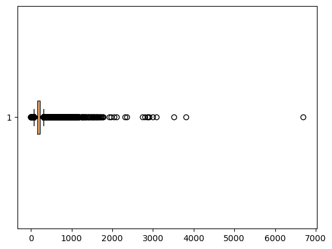

```python
# Distribution du nombre de mots
print("Distribution du nombre de mots :")
print(articles_metadata['words_count'].describe())
plt.boxplot(articles_metadata['words_count'], vert=False);
```

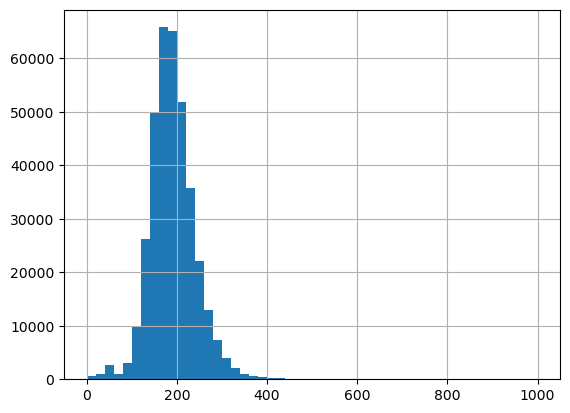

```python
articles_metadata['words_count'].hist(bins=50, range=(0,1000));
```

Nous avons des valeurs aberrantes avec 0 en minimum de mots. Nous allons remplacer ces 0 par le mode.

```python
mode_words_count = articles_metadata['words_count'].mode()[0]
print(mode_words_count)
articles_metadata.loc[articles_metadata['words_count'] == 0, 'words_count'] = mode_words_count
```

```
176
```

Nous pouvons envisager de recommander des articles avec des tailles similaires à ce que l'utilisateur aime lire. Nous allons créer 3 catégories : small, medium, long. Comme nous avons une distribution similaire à une gaussienne (centrée autour de la moyenne) nous allons utiliser les écarts-types autour de la moyenne.

- Small (court) : Articles dont le nombre de mots est inférieur à la moyenne moins un écart-type.
- Medium (moyen) : Articles dont le nombre de mots est entre la moyenne moins un écart-type et la moyenne plus un écart-type.
- Long (long) : Articles dont le nombre de mots est supérieur à la moyenne plus un écart-type.

```python
mean_words_count = articles_metadata['words_count'].mean()
std_words_count = articles_metadata['words_count'].std()
small_threshold = mean_words_count - std_words_count
medium_threshold = mean_words_count + std_words_count
print('small_threshold :', small_threshold )
print('medium_threshold :', medium_threshold)

# catégorisation
def categorize_article_size(word_count):
    if word_count <= small_threshold:
        return 'small'
    elif word_count <= medium_threshold:
        return 'medium'
    else:
        return 'long'

articles_metadata['article_size'] = articles_metadata['words_count'].apply(categorize_article_size)
print(articles_metadata['article_size'].value_counts())
```

```
small_threshold : 131.44115328227605
medium_threshold : 250.38814348435022
article_size
medium    294782
long       38243
small      31022
Name: count, dtype: int64
```

### category_id

```python
# Distribution des catégories
category_counts = articles_metadata['category_id'].value_counts()
print(category_counts)
print("\nDistribution des catégories :")
category_counts.describe()
```

```
category_id
281    12817
375    10005
399     9049
412     8648
431     7759
       ...
341        1
121        1
335        1
131        1
0          1
Name: count, Length: 461, dtype: int64

Distribution des catégories :
```

```
count      461.000000
mean       789.689805
std       1712.041053
min          1.000000
25%          7.000000
50%         36.000000
75%        520.000000
max      12817.000000
Name: count, dtype: float64
```

50 % des catégories son représentées par 36 articles et moins, ce qui est assez peu. Pour rendre notre recommendation de contenu moins fine, nous pourrions envisager de créer de nouvelles catégories plus générales. Pour cela nous pouvons utiliser les embeddings et créer des catégories en fonction de ces embeddings.

De plus, les catégories dans les métadonnées peuvent être définies de manière générale ou imparfaite. Deux articles qui sont très similaires en termes de contenu pourraient être placés dans des catégories différentes en raison de légères différences ou d'une classification humaine ou automatique qui manque de précision. C'est pourquoi créer de nouvelles catégories à partir des embeddings pourrait être plus intéressant pour rapprocher les articles ayant le même thème (embedding proches)

### articles_embeddings

1. Réduction de dimension :

Nous allons réduire une première fois les dimensions par PCA en gardant 95% des informations. (Cela permettra d'éliminer le "bruit" et réduire la dimensionnalité, ce qui rend t-SNE plus rapide et plus efficace). Puis nous utiliserons la t-SNE pour réduire les dimensions des embeddings à 2 afin de vérifier si une clusterisation est possible.

```python
# Réduction pca
pca = PCA(n_components=0.95, random_state=42)
articles_embeddings_pca = pca.fit_transform(articles_embeddings)
print(f"Nouvelle dimension après PCA : {articles_embeddings_pca.shape}")
```

```
Nouvelle dimension après PCA : (364047, 52)
```

```python
# Réduction tsne
tsne = TSNE(n_components=2, random_state=42)
embeddings_2d = tsne.fit_transform(articles_embeddings_pca)
```

```python
with open('embeddings_2d.pkl', 'wb') as file:
    pickle.dump(embeddings_2d, file)

print("Les embeddings réduits ont été enregistrés sous le nom 'embeddings_2d.pkl'.")
```

```
Les embeddings réduits ont été enregistrés sous le nom 'embeddings_2d.pkl'.
```

```python
with open('embeddings_2d.pkl', 'rb') as f:
    embeddings_2d = pickle.load(f)
```

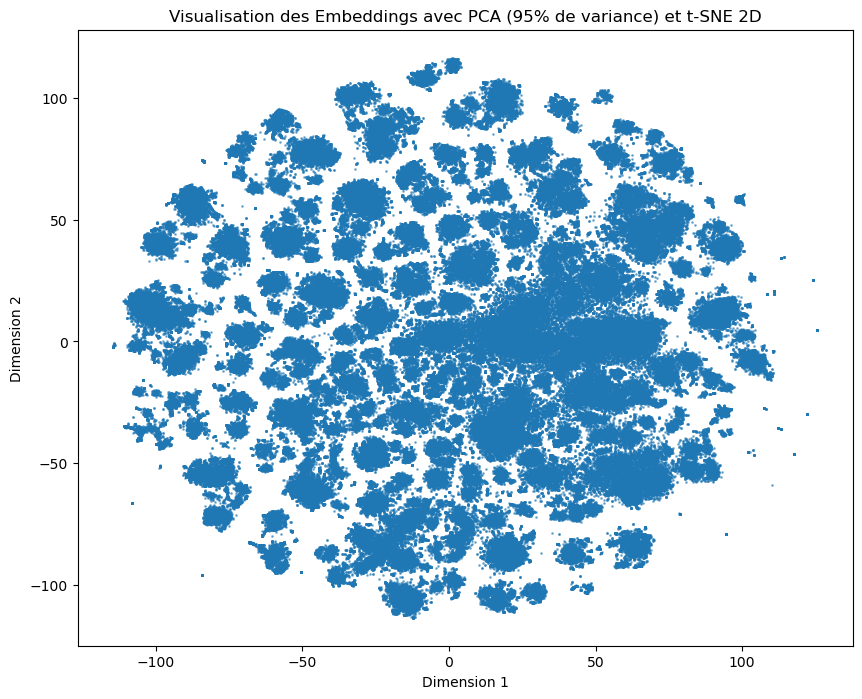

```python
plt.figure(figsize=(10, 8))
plt.scatter(embeddings_2d[:, 0], embeddings_2d[:, 1], s=1, alpha=0.5)
plt.title("Visualisation des Embeddings avec PCA (95% de variance) et t-SNE 2D")
plt.xlabel("Dimension 1")
plt.ylabel("Dimension 2")
plt.show()
```

Pour rappel :

- t-SNE : Met l'accent sur la préservation des distances locales, ce qui signifie que les points et clusters qui sont proches dans l'espace réduit sont probablement proches dans l'espace d'origine aussi.
- PCA : Conserve les relations linéaires entre les dimensions originales. Si les clusters sont proches dans l'espace réduit par PCA, cela indique une similarité en termes de combinaisons linéaires des caractéristiques d'origine.

Nous pouvons voir un grand nombre de petits clusters suggérant qu'une clusterisation est possible. Certains clusters sont très proches voir chevauchant indiquant qu'ils partagent certaines caractéristiques communes, un regroupement de ces clusters seraient donc envisageables. D'autres clusters ont une grande distance entre eux indiquant des caractéristiques distinctes. Il faut donc trouver un nombre de k suffisemment élevé pour ne pas regrouper des embeddings très différents, mais suffisemment bas pour regrouper les embeddings ayant des caractéristiques proches.

2. Recherche du k optimal

```python
# Normaliser les embeddings pour que la distance Euclidienne équivaut à la similarité cosinus
normalized_embeddings = normalize(articles_embeddings)
```

```python
k_values = range(150,250)
inertias = []

# Calculer de l'inertie (somme des distances au carré)
for k in k_values:
    kmeans = KMeans(n_clusters=k, random_state=42)
    kmeans.fit(normalized_embeddings)
    inertias.append(kmeans.inertia_)
```

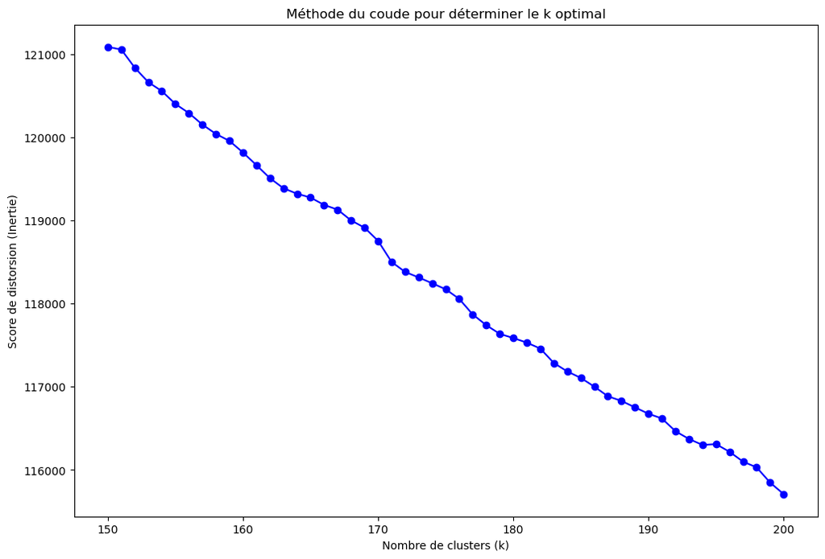

```python
# Tracer le graphique pour observer un éventuel coude
filtered_k_values = [k for k in k_values if 150 <= k <= 200]
filtered_inertias = [inertia for k, inertia in zip(k_values, inertias) if 150 <= k <= 200]
plt.figure(figsize=(12, 8))
plt.plot(filtered_k_values, filtered_inertias, 'bo-')
plt.xlabel('Nombre de clusters (k)')
plt.ylabel('Score de distorsion (Inertie)')
plt.title('Méthode du coude pour déterminer le k optimal')
plt.show()
```

```python
k_optimal = 172
```

```python
kmeans = KMeans(n_clusters=k_optimal, random_state=42)
optimal_clusters = kmeans.fit_predict(normalized_embeddings)
```

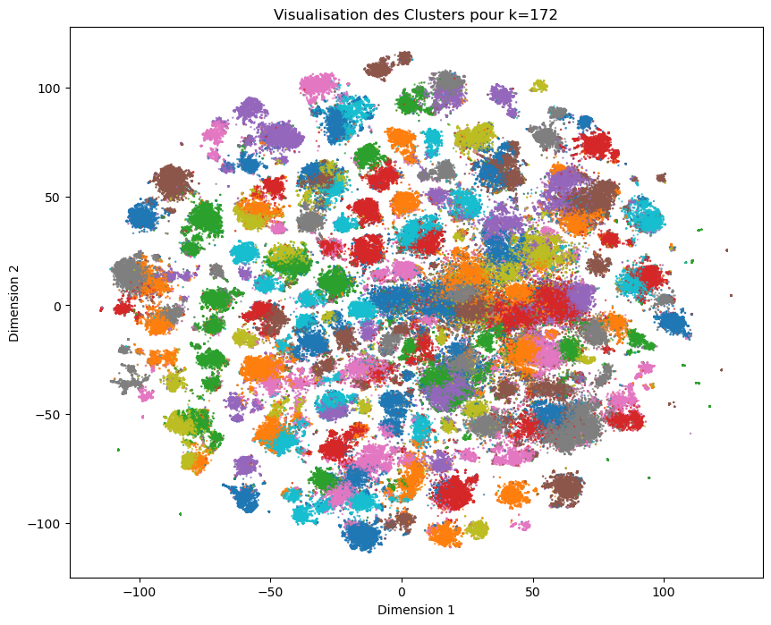

```python
plt.figure(figsize=(10, 8))
plt.scatter(embeddings_2d[:, 0], embeddings_2d[:, 1], c=optimal_clusters, cmap='tab10', s=0.5, alpha=0.7)
plt.title(f'Visualisation des Clusters pour k={k_optimal}')
plt.xlabel('Dimension 1')
plt.ylabel('Dimension 2')
plt.show()
```

3. Clusterisation des catégories en 172 groupes

```python
kmeans = KMeans(n_clusters=k_optimal, random_state=42)
category_clusters = kmeans.fit_predict(normalized_embeddings)
articles_metadata['id_cluster_embedding'] = category_clusters
```

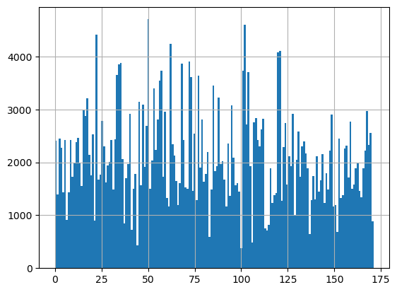

```python
articles_metadata['id_cluster_embedding'].hist(bins=k_optimal);
```

## 3.2 clicks_data

```python
# Statistiques descriptives générales
clicks_data.describe().transpose()
```

|  | count | unique | top | freq |
| --- | --- | --- | --- | --- |
| user_id | 2988181 | 322897 | 5890 | 1232 |
| session_id | 2988181 | 1048594 | 1507563657895091 | 124 |
| session_size | 2988181 | 72 | 2 | 1260372 |
| click_article_id | 2988181 | 46033 | 160974 | 37213 |

### user_id

```python
user_clicks = clicks_data['user_id'].value_counts()
print("Distribution du nombre de clics par utilisateur :")
user_clicks.describe()
```

```
Distribution du nombre de clics par utilisateur :
```

```
count    322897.000000
mean          9.254285
std          14.946358
min           2.000000
25%           2.000000
50%           4.000000
75%          10.000000
max        1232.000000
Name: count, dtype: float64
```

50% des utilisateurs ont cliqué sur 4 articles et moins.

### click_article_id

```python
# Distribution du nombre de clic par article
article_clicks = clicks_data['click_article_id'].value_counts()
print("Distribution du nombre de clics par article consultés :")
print(article_clicks.describe())
```

```
Distribution du nombre de clics par article consultés :
count    46033.000000
mean        64.913888
std        629.322888
min          1.000000
25%          1.000000
50%          1.000000
75%          6.000000
max      37213.000000
Name: count, dtype: float64
```

50% des articles consultés n'ont été cliqués qu'une seule fois (un seul utilisateur)

```python
article_clicks.sort_values(ascending=False).head(5)
```

```
click_article_id
160974    37213
272143    28943
336221    23851
234698    23499
123909    23122
Name: count, dtype: int64
```

```python
# sauvegarde de clicks_data et articles_metadata
clicks_data.to_csv('clicks_data.csv', index=False)
articles_metadata.to_csv('articles_metadata.csv', index=False)
```

```python
clicks_data=pd.read_csv('clicks_data.csv')
articles_metadata=pd.read_csv('articles_metadata.csv')
```

# 4.Filtrage collaboratif (Collaborative-Filtering)

Le collaborative filtering (ou filtrage collaboratif) est une technique utilisée dans les systèmes de recommandation pour proposer un item (ici article) à un utilisateur en se basant sur les informations provenant des autres utilisateurs. L'idée fondamentale du filtrage collaboratif est que si des utilisateurs partagent des intérêts similaires, alors les préférences d'un utilisateur peuvent être prédites en utilisant les préférences des autres utilisateurs similaires.

Il existe 2 types de collaborative filtering :

1. Filtrage collaboratif basé sur les utilisateurs (User-Based Collaborative Filtering) : Cette approche recommande des items (articles) à un utilisateur en fonction des préférences d'autres utilisateurs qui lui ressemblent.
   - Avantages :
     - Facile à implémenter si les utilisateurs ont des comportements bien définis.
     - Fonctionne bien lorsque les utilisateurs partagent des goûts similaires.
   - Inconvénients :
     - Scalabilité : Trouver des utilisateurs similaires devient coûteux en termes de calcul lorsque le nombre d’utilisateurs augmente.
     - Cold Start Problem : Difficulté à recommander pour les nouveaux utilisateurs ou les utilisateurs avec peu d’interactions, car il n’y a pas assez de données pour trouver des utilisateurs similaires.
2. Filtrage collaboratif basé sur les items (Item-Based Collaborative Filtering) : Ici, la recommandation est basée sur la similarité entre les items eux-mêmes. On identifie les articles similaires en fonction de la manière dont les utilisateurs les ont notés ou consultés. Par exemple, deux articles peuvent être considérés comme similaires si beaucoup d’utilisateurs les ont appréciés ensemble.
   - Avantages :
     - Scalabilité : Les similarités entre articles changent moins souvent que celles entre utilisateurs, donc une fois calculées, elles sont plus stables.
     - Fonctionne bien dans les systèmes où il y a un grand nombre d’articles avec beaucoup d’interactions.
   - Inconvénients :
     - Peut être moins efficace si les articles sont très diversifiés et ne sont pas fréquemment associés.

Il y a deux types d'interactions utilisateurs-articles que l'on peut utiliser :

1. Interactions explicites : Les notes attribuées directement par les utilisateurs (par exemple, une évaluation de 1 à 5 étoiles) sont des données explicites.
2. Interactions implicites : Les données comme les clics, les vues, ou les achats peuvent aussi être utilisées pour inférer les préférences de l'utilisateur.

Ici nous n'avons pas de notes. Les interactions que l'on peut utiliser sont les clics.

```python
# Regroupement des données pour compter le nombre de clics par utilisateur-article
clicks_data_grouped = clicks_data.groupby(['user_id', 'click_article_id']).size().reset_index(name='clicks')
print(clicks_data_grouped.head())
```

```
   user_id  click_article_id  clicks
0        0             68866       1
1        0             87205       1
2        0             87224       1
3        0             96755       1
4        0            157541       1
```

Surprise

- La bibliothèque Surprise est dédiée aux systèmes de recommandation, en particulier ceux basés sur des algorithmes de filtrage collaboratif. Elle est principalement utilisée pour prédire les préférences des utilisateurs sur des items (articles, films, etc.) à partir des interactions précédentes.
- Surprise implémente à la fois des algorithmes User-Based Collaborative Filtering et Item-Based Collaborative Filtering en se basant sur les notes (de 1 à 5). Dans Surprise, on peut traiter des données implicites en transformant les clics ou les interactions en une note entre 1 et 5, ce qui est l'objectif ici.
- Les principales métriques utilisées dans Surprise sont :
  - RMSE (Root Mean Squared Error) : Mesure l'erreur moyenne entre les notes prédites et les notes réelles. Plus elle est faible, meilleure est la précision du modèle.
  - MAE (Mean Absolute Error) : Mesure l’erreur absolue moyenne entre les notes prédites et réelles.

```python
print("Nombre de clics par article spécifique pour chaque utilisateur:")
clicks_data_grouped['clicks'].value_counts().sort_index()
```

```
Nombre de clics par article spécifique pour chaque utilisateur:
```

```
clicks
1     2916835
2       31459
3        1869
4         343
5          95
6          42
7          22
8          14
9           7
10          7
12          3
13          6
16          2
17          1
30          1
31          1
33          3
Name: count, dtype: int64
```

```python
def transform_clicks_to_ratings(clicks):
    if clicks >= 9:
        return 5
    elif clicks >= 4:
        return 4
    elif clicks >= 3:
        return 3
    elif clicks >= 2:
        return 2
    else:
        return 1

# Transformation des clics en niveau d'intérêt (rating) pour surprise
clicks_data_grouped['interest'] = clicks_data_grouped['clicks'].apply(transform_clicks_to_ratings)
clicks_data_grouped['interest'].value_counts().sort_index()
```

```
interest
1    2916835
2      31459
3       1869
4        516
5         31
Name: count, dtype: int64
```

```python
clicks_data_grouped['interest'].describe()
```

```
count    2.950710e+06
mean     1.012495e+00
std      1.215770e-01
min      1.000000e+00
25%      1.000000e+00
50%      1.000000e+00
75%      1.000000e+00
max      5.000000e+00
Name: interest, dtype: float64
```

```python
# Préparation des données avec séparation des ensembles
reader = Reader(rating_scale=(1, 5))
data = Dataset.load_from_df(clicks_data_grouped[['user_id', 'click_article_id', 'interest']], reader)
trainset, testset = train_test_split(data, test_size=0.2)
```

Approche User-based

```python
# hyperparamètres
param_grid = {
    'n_factors': [20, 50],
    'n_epochs': [10, 20],
    'lr_all': [0.002, 0.005],
    'reg_all': [0.02, 0.1]
}

# Recherche
gs = GridSearchCV(SVD, param_grid, measures=['rmse', 'mae'], cv=3)
gs.fit(data)

print(f"Meilleurs paramètres : {gs.best_params['rmse']}")

# Évaluation
best_model = SVD(n_factors= 20,
                 n_epochs=30,
                 lr_all=0.002,
                 reg_all=0.4)
best_model.fit(trainset)
predictions = best_model.test(testset)
print(f"RMSE pour SVD User-based : {accuracy.rmse(predictions)}")
```

```
Meilleurs paramètres : {'n_factors': 20, 'n_epochs': 20, 'lr_all': 0.002, 'reg_all': 0.1}
RMSE: 0.1191
RMSE pour SVD User-based : 0.11905004385453401
```

La RMSE (Root Mean Square Error) mesure l'écart moyen entre les prédictions du modèle et les valeurs réelles. Une RMSE de 0.119 est très faible, ce qui suggère que les prédictions du modèle sont très proches des valeurs observées. Cependant, dans notre cas, la distribution des intérêts est très déséquilibrée : 75% des valeurs sont à 1. Cela signifie que le modèle pourrait prédire la valeur 1 systématiquement et obtenir une RMSE faible, sans réellement capturer des patterns intéressants ou des nuances dans les données. Une analyse des prédictions sur les intérêts supérieurs à 1, serait plus utile pour évaluer la performance du modèle dans ce contexte.

```python
predictions_above_1 = [pred for pred in predictions if pred.r_ui > 1]
rmse_above_1 = accuracy.rmse(predictions_above_1, verbose=True)
print(f"RMSE pour les intérêts > 1 : {rmse_above_1}")
```

```
RMSE: 1.0869
RMSE pour les intérêts > 1 : 1.086861929134235
```

Recommendations

Vérifions nos intuitions en faisant des recommendations. Attention il faut filtrer les articles déjà vus par l'utilisateur.

```python
def get_recommendations_for_user(user_id, model, trainset, original_data, n_recommendations=5):
    inner_user_id = trainset.to_inner_uid(user_id)
    # Filtre les articles déjà vus
    seen_articles = set(original_data[original_data['user_id'] == user_id]['click_article_id'])
    # Liste les articles uniques
    all_article_ids = original_data['click_article_id'].unique()
    # Prédit l'intérêt pour les articles non vus
    known_article_ids = [article_id for article_id in all_article_ids if article_id in trainset._raw2inner_id_items]
    recommendations = []
    for article_id in known_article_ids:
        if article_id not in seen_articles:
            inner_article_id = trainset.to_inner_iid(article_id)
            predicted_rating = model.predict(uid=inner_user_id, iid=inner_article_id).est
            recommendations.append((article_id, predicted_rating))
    # Trie les articles par intérêt
    recommendations.sort(key=lambda x: x[1], reverse=True)
    # Retourne les top recommandations (note d'intérêt la plus élevée)
    return recommendations[:n_recommendations]

user_id = 1000
recommendations = get_recommendations_for_user(user_id, best_model, trainset, clicks_data_grouped, n_recommendations=5)
for article_id, rating in recommendations:
    print(f"Article ID: {article_id}, Note prédite: {rating:.2f}")
```

[output not shown]

Comme nous avons uniquement des id_article, et pas le titre de l'article qui pourrait nous donner un indice de la pertinence des recommendations, nous allons regarder les catégories déjà vues par l'utilisateur et les catégories recommendées pour se donner une idée.

```python
# Création d'un dataframe avec les articles + embedding et catégories associées déjà vus par l'utilisateur
def get_user_articles_and_categories(user_id, train_data, articles_metadata):
    user_articles = train_data[train_data['user_id'] == user_id]['click_article_id'].unique()
    user_articles_with_categories = articles_metadata[articles_metadata['article_id'].isin(user_articles)][['article_id', 'id_cluster_embedding', 'category_id']]
    user_articles_with_categories['user_id'] = user_id
    return user_articles_with_categories[['article_id', 'id_cluster_embedding']]
```

```python
# Création d'un dataframe avec les articles + embedding et catégories associées proposés pour l'utilisateur
def get_recommended_articles_and_categories(recommendations, articles_metadata, user_id):
    recommended_articles_with_categories = articles_metadata[articles_metadata['article_id'].isin(recommendations)][['article_id', 'id_cluster_embedding', 'category_id']]
    recommended_articles_with_categories['user_id'] = user_id
    return recommended_articles_with_categories[['article_id', 'id_cluster_embedding']]
```

```python
user_articles_df = get_user_articles_and_categories(user_id=user_id, train_data=clicks_data_grouped, articles_metadata=articles_metadata)
print(f"Articles déjà vus par l'utilisateur {user_id}:")
print(user_articles_df.to_string(index=False))

recommended_articles_df = get_recommended_articles_and_categories(recommendations, articles_metadata, user_id=user_id)
print(f"\nArticles recommandés pour l'utilisateur {user_id}:")
print(recommended_articles_df.to_string(index=False))
```

```
Articles déjà vus par l'utilisateur 1000:
 article_id  id_cluster_embedding
     119592                   101
     123757                    81
     145166                    58
     215861                   160
     235840                    25
     284847                    73
     331293                    53
     331738                    53

Articles recommandés pour l'utilisateur 1000:
 article_id  id_cluster_embedding
      67602                    54
     108692                   106
     318329                    11
     324154                    28
     324328                    28
```

D'après le tableau, aucun des articles prédits n'est dans la meme catégorie ou groupe d'embedding des articles déjà lus.

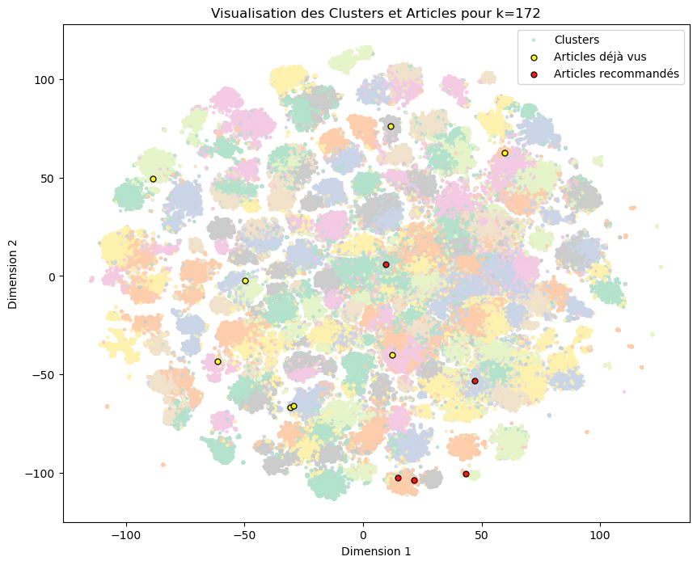

```python
# Extrait les indices des articles vus et recommandés
user_seen_articles = user_articles_df['article_id'].values
recommended_articles = recommended_articles_df['article_id'].values

# Création d'un masque pour repérer les indices correspondants dans l'embedding
seen_mask = [index for index, article_id in enumerate(articles_metadata['article_id']) if article_id in user_seen_articles]
recommended_mask = [index for index, article_id in enumerate(articles_metadata['article_id']) if article_id in recommended_articles]

# visualisation
plt.figure(figsize=(10, 8))
plt.scatter(embeddings_2d[:, 0], embeddings_2d[:, 1], c=optimal_clusters, cmap='Pastel2', s=5, alpha=0.8, label="Clusters")
plt.scatter(embeddings_2d[seen_mask, 0], embeddings_2d[seen_mask, 1], s=25, alpha=0.9, color='yellow', edgecolor='black', label="Articles déjà vus")
plt.scatter(embeddings_2d[recommended_mask, 0], embeddings_2d[recommended_mask, 1], s=25, alpha=0.9, color='red', edgecolor='black', label="Articles recommandés")
plt.title(f"Visualisation des Clusters et Articles pour k={k_optimal}")
plt.xlabel("Dimension 1")
plt.ylabel("Dimension 2")
plt.legend(loc="best")
plt.show()
```

Les articles prédits sont non seulement dans aucun des groupes d'embedding des articles déjà lus, mais en plus ils sont loin (en distance et donc en terme de thème général) des articles déjà lus. Nos prédictions ne semblent pas être bonnes du tout.

Limites

Le problème actuel avec nos données c'est que seulement 12% des articles ont été consultés (cliqués) et la moitié de ces 12% n'a été consulté que par un seul utilisateur, ce qui limite fortement la pertinence du collaborative filtering, car :

- Dans le User-Based Filtering, il est difficile de trouver des utilisateurs ayant des goûts similaires puisque la plupart des utilisateurs a consulté des articles différents des autres.
- Dans le Item-Based Filtering, il est difficile de trouver des articles similaires entre eux, car il n'y a pas suffisamment d’utilisateurs ayant interagi avec les mêmes articles.

Dans ce type de scénario avec peu de chevauchement, les deux techniques souffrent des problèmes suivants :

- Sparsité des données : La matrice utilisateur-article devient très éparse, avec beaucoup de zéros. Cela rend difficile l’identification des similarités utiles.
- Cold Start Problem généralisé : Même pour les utilisateurs ou articles existants, les données sont trop fragmentées pour construire des recommandations robustes.

Solutions alternatives : Filtrage basé sur le contenu (Content-Based Filtering)

# 5. Filtrage basé sur le contenu (Content-Based Filtering) :

Plutôt que de se baser sur les interactions des utilisateurs, cette méthode recommande des articles similaires en fonction des attributs des articles eux-mêmes (par exemple, le texte des articles, les catégories, les tags). Si les articles ont des métadonnées riches, cette approche peut être efficace même avec peu de chevauchement entre les utilisateurs. Ici nous pouvons utiliser les id_cluster_embedding qui utilise les embeddings des articles ainsi que la taille des articles.

Étapes

1.Identifier les articles que l’utilisateur a déjà vus ou aimés à partir de clicks_data.

2.Utiliser les caractéristiques des articles (cluster d'embeddings et taille) dans articles_metadata pour trouver des articles similaires.

3.Recommander des articles similaires que l’utilisateur n’a pas encore vus.

```python
def recommend_articles(user_id, clicks_data, articles_metadata, n_recommendations=5):
    # articles déjà vus par l'utilisateur
    user_articles = clicks_data[clicks_data['user_id'] == user_id]['click_article_id'].unique()
    # les clusters et tailles des articles déjà vus
    user_clusters = articles_metadata[articles_metadata['article_id'].isin(user_articles)]['id_cluster_embedding']
    cluster_counts = user_clusters.value_counts()

    # Cas 1 : L'utilisateur n'a lu qu'un seul article
    if len(user_articles) == 1:
        single_cluster = user_clusters.iloc[0]
        candidate_articles = articles_metadata[(articles_metadata['id_cluster_embedding'] == single_cluster) &
                                               (~articles_metadata['article_id'].isin(user_articles))]
        # Prioriser les articles de taille similaire
        preferred_size = articles_metadata[articles_metadata['article_id'] == user_articles[0]]['article_size'].iloc[0]
        filtered_candidates = candidate_articles[candidate_articles['article_size'] == preferred_size]

        # Si pas assez d'articles avec la taille préférée, ajouter d'autres tailles
        if len(filtered_candidates) < n_recommendations:
            additional_candidates = candidate_articles[candidate_articles['article_size'] != preferred_size]
            recommendations = pd.concat([filtered_candidates, additional_candidates]).head(n_recommendations)
        else:
            recommendations = filtered_candidates.head(n_recommendations)

        return recommendations['article_id'].tolist()

    # Cas 2 : L'utilisateur a lu plusieurs articles dans un seul cluster
    if len(cluster_counts) == 1:
        single_cluster = cluster_counts.index[0]
        candidate_articles = articles_metadata[(articles_metadata['id_cluster_embedding'] == single_cluster) &
                                               (~articles_metadata['article_id'].isin(user_articles))]
        # Prioriser les articles de taille similaire
        preferred_sizes = articles_metadata[articles_metadata['article_id'].isin(user_articles)]['article_size'].unique()
        filtered_candidates = candidate_articles[candidate_articles['article_size'].isin(preferred_sizes)]

        # Si pas assez d'articles avec les tailles préférées, ajouter d'autres tailles
        if len(filtered_candidates) < n_recommendations:
            additional_candidates = candidate_articles[~candidate_articles['article_id'].isin(filtered_candidates['article_id'])]
            recommendations = pd.concat([filtered_candidates, additional_candidates]).head(n_recommendations)
        else:
            recommendations = filtered_candidates.head(n_recommendations)

        return recommendations['article_id'].tolist()

    # Cas 3 : L'utilisateur a lu des articles dans plusieurs clusters
    recommendations = []
    for cluster_id, count in cluster_counts.items():
        # Limiter à 3 articles pour assurer la diversité
        n_cluster_recommendations = min(count, 3, n_recommendations - len(recommendations))

        candidate_articles = articles_metadata[(articles_metadata['id_cluster_embedding'] == cluster_id) &
                                               (~articles_metadata['article_id'].isin(user_articles))]

        # Prioriser les articles de taille similaire
        preferred_sizes = articles_metadata[articles_metadata['article_id'].isin(user_articles) &
                                            (articles_metadata['id_cluster_embedding'] == cluster_id)]['article_size'].unique()
        filtered_candidates = candidate_articles[candidate_articles['article_size'].isin(preferred_sizes)]

        # Si pas assez d'articles avec les tailles préférées, ajouter d'autres tailles
        if len(filtered_candidates) < n_cluster_recommendations:
            additional_candidates = candidate_articles[~candidate_articles['article_id'].isin(filtered_candidates['article_id'])]
            selected_articles = pd.concat([filtered_candidates, additional_candidates]).head(n_cluster_recommendations)
        else:
            selected_articles = filtered_candidates.head(n_cluster_recommendations)

        recommendations.extend(selected_articles['article_id'].tolist())

        # Si on a atteint le nombre total de recommandations, arrêter
        if len(recommendations) >= n_recommendations:
            break

    return recommendations[:n_recommendations]
```

Stratégie de recommendation:

1. Si l'utilisateur n'a lu qu'un seul article :

Proposer 5 articles du même cluster (en excluant l'article déjà lu), en privilégiant d'abord les articles de même taille, puis les autres tailles si nécessaire.

2. Si l'utilisateur a lu plusieurs articles mais tous dans un seul cluster :

Proposer 5 articles du même cluster (en excluant ceux déjà lus), avec la même logique de taille (d'abord les articles de taille similaire, puis les autres).

3. Si l'utilisateur a lu plusieurs articles dans plusieurs clusters :

Proposer des articles en proportion du nombre d'articles déjà lus par cluster, en respectant les contraintes suivantes : - Ne jamais proposer plus d'articles dans un cluster que le nombre d'articles déjà lus dans ce cluster. - Limiter à 3 articles les recommandations d’un même cluster pour laisser de la place à d’autres clusters. - Filtrer avec la même logique de taille que précédemment.

```python
# Obtenir les recommandations pour un utilisateur
user_id = 1000
recommendations = recommend_articles(user_id=user_id, clicks_data=clicks_data, articles_metadata=articles_metadata)

print(f"Recommandations pour l'utilisateur {user_id} :", recommendations)
```

```
Recommandations pour l'utilisateur 1000 : [3314, 3499, 3883, 29709, 33139]
```

```python
def get_user_articles_and_categories(user_id, clicks_data, articles_metadata):
    user_articles = clicks_data[clicks_data['user_id'] == user_id]['click_article_id'].unique()
    user_articles_with_categories = articles_metadata[articles_metadata['article_id'].isin(user_articles)][['article_id', 'id_cluster_embedding', 'category_id', 'article_size']]
    user_articles_with_categories['user_id'] = user_id
    return user_articles_with_categories[['article_id', 'id_cluster_embedding', 'article_size']]

def get_recommended_articles_and_categories(recommendations, articles_metadata, user_id):
    recommended_articles_with_categories = articles_metadata[articles_metadata['article_id'].isin(recommendations)][['article_id', 'id_cluster_embedding', 'category_id', 'article_size']]
    recommended_articles_with_categories['user_id'] = user_id
    return recommended_articles_with_categories[['article_id', 'id_cluster_embedding', 'article_size']]

# afficher les articles vus et recommandés
user_articles_df = get_user_articles_and_categories(user_id=user_id, clicks_data=clicks_data, articles_metadata=articles_metadata)
recommended_articles_df = get_recommended_articles_and_categories(recommendations, articles_metadata, user_id=user_id)

print(f"Articles déjà vus par l'utilisateur : {user_id} ")
print(user_articles_df.to_string(index=False))

print(f"\nArticles recommandés à l'utilisateur : {user_id}")
print(recommended_articles_df.to_string(index=False))
```

```
Articles déjà vus par l'utilisateur : 1000
 article_id  id_cluster_embedding article_size
     119592                   101       medium
     123757                    81       medium
     145166                    58       medium
     215861                   160         long
     235840                    25       medium
     284847                    73         long
     331293                    53       medium
     331738                    53       medium

Articles recommandés à l'utilisateur : 1000
 article_id  id_cluster_embedding article_size
       3314                    53       medium
       3499                    53       medium
       3883                   101       medium
      29709                    81       medium
      33139                    58       medium
```

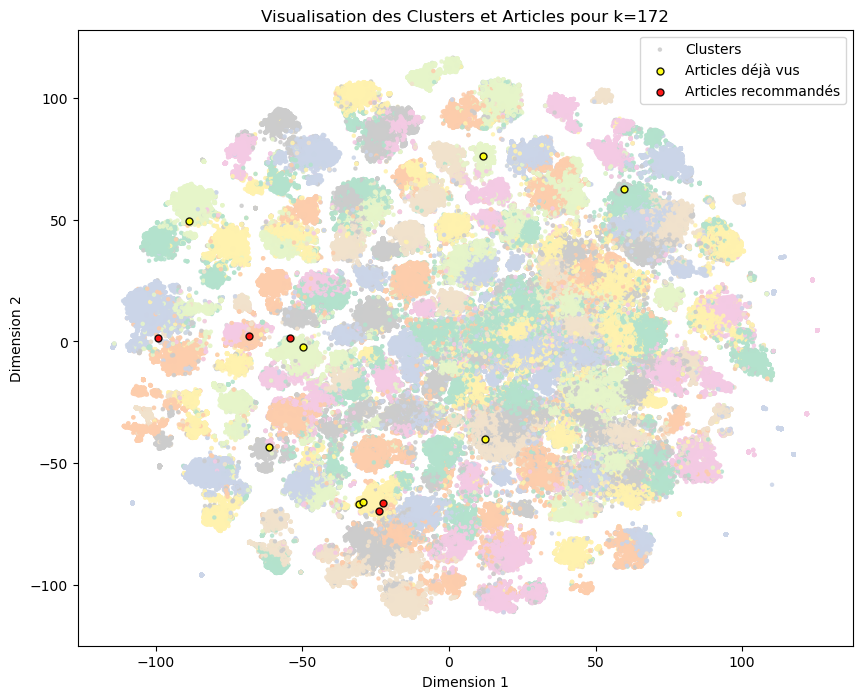

```python
# Extraire les indices des articles vus et recommandés dans les embeddings 2D
user_seen_articles = user_articles_df['article_id'].values
recommended_articles = recommended_articles_df['article_id'].values

# Créer un masque pour repérer les indices correspondants dans l'embedding
seen_mask = [index for index, article_id in enumerate(articles_metadata['article_id']) if article_id in user_seen_articles]
recommended_mask = [index for index, article_id in enumerate(articles_metadata['article_id']) if article_id in recommended_articles]

# Visualisation
plt.figure(figsize=(10, 8))
plt.scatter(embeddings_2d[:, 0], embeddings_2d[:, 1], c=optimal_clusters, cmap='Pastel2', s=5, alpha=0.8, label="Clusters")
plt.scatter(embeddings_2d[seen_mask, 0], embeddings_2d[seen_mask, 1], s=25, alpha=0.9, color='yellow', edgecolor='black', label="Articles déjà vus")
plt.scatter(embeddings_2d[recommended_mask, 0], embeddings_2d[recommended_mask, 1], s=25, alpha=0.9, color='red', edgecolor='black', label="Articles recommandés")
plt.title(f"Visualisation des Clusters et Articles pour k={k_optimal}")
plt.xlabel("Dimension 1")
plt.ylabel("Dimension 2")
plt.legend(loc="best")
plt.show()
```

# 6. Filtrage hybride

Logique globale

```python
class HybridRecommender:
    def __init__(self, clicks_data, articles_metadata, top_n=5):
        self.clicks_data = clicks_data
        self.articles_metadata = articles_metadata
        self.top_n = top_n
        self.top_clicked_articles = self.get_top_clicked_articles()

    def get_top_clicked_articles(self):
        return self.clicks_data['click_article_id'].value_counts().head(self.top_n).index.tolist()

    def get_user_interactions(self, user_id):
        user_interactions = self.clicks_data[self.clicks_data['user_id'] == user_id]
        # Fusionner avec les métadonnées des articles pour récupérer les informations de cluster et de taille
        user_interactions = pd.merge(
            user_interactions,
            self.articles_metadata[['article_id', 'id_cluster_embedding', 'article_size']],
            left_on='click_article_id',
            right_on='article_id',
            how='left'
        )
        return user_interactions

    def get_cluster_click_counts(self, user_id):
        user_interactions = self.get_user_interactions(user_id)
        # Compter les clics par cluster
        cluster_click_counts = user_interactions['id_cluster_embedding'].value_counts()
        return cluster_click_counts

    def recommend_for_new_user(self):
        return self.top_clicked_articles

    def recommend_for_single_interaction(self, user_interactions):
        article_id = user_interactions['click_article_id'].iloc[0]
        if article_id in self.top_clicked_articles:
            recommendations = [art for art in self.top_clicked_articles if art != article_id]
        else:
            recommendations = self.get_content_based_recommendations(article_id)
        return recommendations

    def get_content_based_recommendations(self, article_id):
        cluster_id = self.articles_metadata.loc[self.articles_metadata['article_id'] == article_id, 'id_cluster_embedding'].values[0]
        preferred_size = self.articles_metadata.loc[self.articles_metadata['article_id'] == article_id, 'article_size'].values[0]

        candidate_articles = self.articles_metadata[(self.articles_metadata['id_cluster_embedding'] == cluster_id) &
                                                    (self.articles_metadata['article_id'] != article_id)]
        filtered_candidates = candidate_articles[candidate_articles['article_size'] == preferred_size]

        if len(filtered_candidates) < self.top_n:
            additional_candidates = candidate_articles[candidate_articles['article_size'] != preferred_size]
            recommendations = pd.concat([filtered_candidates, additional_candidates]).head(self.top_n)
        else:
            recommendations = filtered_candidates.head(self.top_n)

        return recommendations['article_id'].tolist()

    def recommend_for_multiple_interactions_same_cluster(self, user_interactions):
        cluster_id = user_interactions['id_cluster_embedding'].iloc[0]
        preferred_sizes = user_interactions['article_size'].unique()

        candidate_articles = self.articles_metadata[(self.articles_metadata['id_cluster_embedding'] == cluster_id) &
                                                    (~self.articles_metadata['article_id'].isin(user_interactions['click_article_id']))]
        filtered_candidates = candidate_articles[candidate_articles['article_size'].isin(preferred_sizes)]

        if len(filtered_candidates) < self.top_n:
            additional_candidates = candidate_articles[~candidate_articles['article_id'].isin(filtered_candidates['article_id'])]
            recommendations = pd.concat([filtered_candidates, additional_candidates]).head(self.top_n)
        else:
            recommendations = filtered_candidates.head(self.top_n)

        return recommendations['article_id'].tolist()

    def recommend_for_multiple_interactions_different_clusters(self, user_interactions):
        # Compter les clics par cluster
        cluster_click_counts = user_interactions['id_cluster_embedding'].value_counts()

        # Trier les clusters en fonction du nombre de clics
        sorted_clusters = cluster_click_counts.sort_values(ascending=False).index

        recommendations = []
        for cluster_id in sorted_clusters:
            n_recommendations = min(cluster_click_counts[cluster_id], 3, self.top_n - len(recommendations))
            candidate_articles = self.articles_metadata[(self.articles_metadata['id_cluster_embedding'] == cluster_id) &
                                                        (~self.articles_metadata['article_id'].isin(user_interactions['click_article_id']))]

            preferred_sizes = user_interactions[user_interactions['id_cluster_embedding'] == cluster_id]['article_size'].unique()
            filtered_candidates = candidate_articles[candidate_articles['article_size'].isin(preferred_sizes)]

            if len(filtered_candidates) < n_recommendations:
                additional_candidates = candidate_articles[~candidate_articles['article_id'].isin(filtered_candidates['article_id'])]
                selected_articles = pd.concat([filtered_candidates, additional_candidates]).head(n_recommendations)
            else:
                selected_articles = filtered_candidates.head(n_recommendations)

            recommendations.extend(selected_articles['article_id'].tolist())
            if len(recommendations) >= self.top_n:
                break

        return recommendations[:self.top_n]

    def get_recommendations(self, user_id):
        user_interactions = self.get_user_interactions(user_id)

        if user_interactions.empty:
            return self.recommend_for_new_user()

        if len(user_interactions) == 1:
            return self.recommend_for_single_interaction(user_interactions)

        user_clusters = user_interactions['id_cluster_embedding'].value_counts()
        if len(user_clusters) == 1:
            return self.recommend_for_multiple_interactions_same_cluster(user_interactions)
        else:
            return self.recommend_for_multiple_interactions_different_clusters(user_interactions)

    def get_cluster_click_counts_df(self, user_id):
        cluster_click_counts = self.get_cluster_click_counts(user_id)
        df = pd.DataFrame({'id_cluster_embedding': cluster_click_counts.index, 'clicks_count': cluster_click_counts.values})
        return df
    # possibilité d'ajouter un nouvel user et article
    def add_new_user(self):
        new_user_id = self.clicks_data['user_id'].max() + 1
        print(f"New user ID created: {new_user_id}")
        return new_user_id

    def add_new_article(self):
        new_article_id = self.articles_metadata['article_id'].max() + 1
        words_count = int(input("Enter the word count for the new article: "))
        available_clusters = self.articles_metadata['id_cluster_embedding'].unique()
        print(f"Available clusters: {available_clusters}")
        cluster_choice = int(input("Select a cluster ID from the available clusters: "))

        # Catégorisation de la taille de l'article
        mean_words_count = self.articles_metadata['words_count'].mean()
        std_words_count = self.articles_metadata['words_count'].std()
        small_threshold = mean_words_count - std_words_count
        medium_threshold = mean_words_count + std_words_count

        def categorize_article_size(word_count):
            if word_count <= small_threshold:
                return 'small'
            elif word_count <= medium_threshold:
                return 'medium'
            else:
                return 'long'

        article_size = categorize_article_size(words_count)

        # Ajouter l'article dans le dataframe des métadonnées
        new_article = pd.DataFrame({
            'article_id': [new_article_id],
            'words_count': [words_count],
            'id_cluster_embedding': [cluster_choice],
            'article_size': [article_size]
        })

        self.articles_metadata = pd.concat([self.articles_metadata, new_article], ignore_index=True)
        print(f"New article added with ID: {new_article_id}")
```

```python
recommender = HybridRecommender(clicks_data, articles_metadata, top_n=5)
user_id = 1000

# Obtenir les recommandations
recommendations = recommender.get_recommendations(user_id)
print(f"Recommandations pour l'utilisateur {user_id} : {recommendations}")
```

```
Recommandations pour l'utilisateur 1000 : [3314, 3499, 3883, 1670, 76033]
```

```python
cluster_clicks_df = recommender.get_cluster_click_counts_df(user_id)
print(cluster_clicks_df)
```

```
   id_cluster_embedding  clicks_count
0                    53             2
1                   101             1
2                    25             1
3                    73             1
4                    58             1
5                   160             1
6                    81             1
```

```python
user_articles_df = get_user_articles_and_categories(user_id=user_id, clicks_data=clicks_data, articles_metadata=articles_metadata)
recommended_articles_df = get_recommended_articles_and_categories(recommendations, articles_metadata, user_id=user_id)

print(f"Articles déjà vus par l'utilisateur : {user_id} ")
print(user_articles_df.to_string(index=False))

print(f"\nArticles recommandés à l'utilisateur : {user_id}")
print(recommended_articles_df.to_string(index=False))
```

```
Articles déjà vus par l'utilisateur : 1000
 article_id  id_cluster_embedding article_size
     119592                   101       medium
     123757                    81       medium
     145166                    58       medium
     215861                   160         long
     235840                    25       medium
     284847                    73         long
     331293                    53       medium
     331738                    53       medium

Articles recommandés à l'utilisateur : 1000
 article_id  id_cluster_embedding article_size
       1670                    25       medium
       3314                    53       medium
       3499                    53       medium
       3883                   101       medium
      76033                    73         long
```

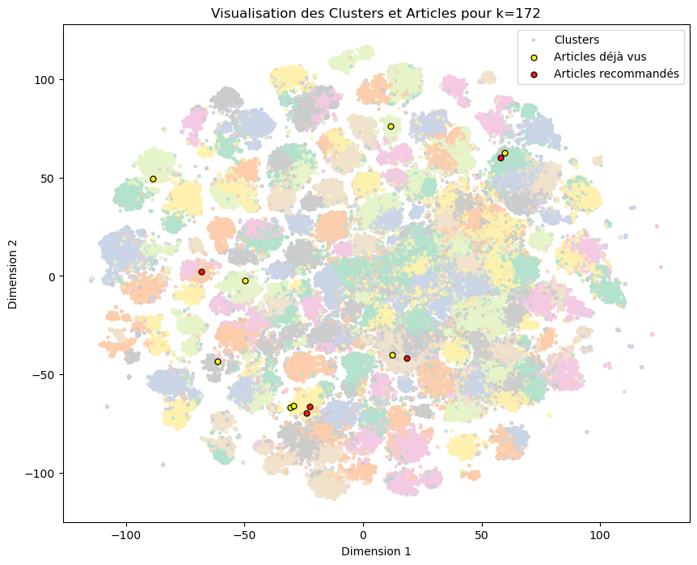

```python
# Extraire les indices des articles vus et recommandés dans les embeddings 2D
user_seen_articles = user_articles_df['article_id'].values
recommended_articles = recommended_articles_df['article_id'].values

# Créer un masque pour repérer les indices correspondants dans l'embedding
seen_mask = [index for index, article_id in enumerate(articles_metadata['article_id']) if article_id in user_seen_articles]
recommended_mask = [index for index, article_id in enumerate(articles_metadata['article_id']) if article_id in recommended_articles]

# Visualisation
plt.figure(figsize=(10, 8))
plt.scatter(embeddings_2d[:, 0], embeddings_2d[:, 1], c=optimal_clusters, cmap='Pastel2', s=5, alpha=0.8, label="Clusters")
plt.scatter(embeddings_2d[seen_mask, 0], embeddings_2d[seen_mask, 1], s=25, alpha=0.9, color='yellow', edgecolor='black', label="Articles déjà vus")
plt.scatter(embeddings_2d[recommended_mask, 0], embeddings_2d[recommended_mask, 1], s=25, alpha=0.9, color='red', edgecolor='black', label="Articles recommandés")
plt.title(f"Visualisation des Clusters et Articles pour k={k_optimal}")
plt.xlabel("Dimension 1")
plt.ylabel("Dimension 2")
plt.legend(loc="best")
plt.show()
```

Cette technique hybride semble plus pertinente que le collaborative filtering tout en étant plus polyvalente que le content-based. C'est celle-ci que nous utiliserons pour créer notre système de recommandation.